# Homework 2

Author

Abby Schmitt

Published

May 30, 2025

## Before your start the assignment

- Update the header - put your name in the `author` argument and put today’s date in the `date` argument.
- Click the “Render” button in RStudio and then open the rendered `2-hw2.html` page.
- Then go back and try changing the `theme` argument in the header to something else - you can see other available themes [here](https://quarto.org/docs/output-formats/html-themes.html). Notice the difference when you render now!

## Overview of HW2

Create a data visualization that helps answer the question:

> **How have the number and cost of billion-dollar disasters in the US changed over time?**

You will use the NOAA Billion-Dollar Disaster dataset to explore how visual encoding choices (e.g., color, position, length) help communicate trends clearly and effectively.

**Skills practiced**:

- Downloading and importing real-world data from a public source (NOAA)
- Wrangle and explore a real-world dataset using tidyverse
- Identify appropriate visual encodings based on variable types and goals
- Create a clear and effective time-series visualization with ggplot2
- Apply design principles (titles, colors, themes, alt text) for accessibility and clarity

### Load Required Packages

```r
library(tidyverse)
library(janitor)
#install.packages("gghighlight") #install and load gghighlight
library(gghighlight)
#install.packages("scales") #install and load scales for scaling logic in visualization
library(scales)
# load other packages as you see fit but remember to add comments to explain what each package does
```

## Q1: Prepare the data

Following these steps to download and read in the dataset:

1. Download the dataset from [NOAA](https://www.ncei.noaa.gov/access/metadata/landing-page/bin/iso?id=gov.noaa.nodc:0209268). Under “Access” tab, choose the HTTPS option to download the data. Scroll to the bottom of the list to download the **most recent published version**. Read more about the dataset [here](https://www.ncei.noaa.gov/access/billions/).
2. Place the downloaded CSV file `events-US-1980-2024-Q4.csv` into your `data/` folder in your HW repository. You will notice there is a graph that comes with the data, we will circle back to it later.
3. Add your data/ folder to .gitignore to avoid pushing data to GitHub.
4. Read in the CSV file using `read_csv()`

```r
# remove the eval=FALSE when you render quarto document
df_disasters <- read_csv("data/events-US-1980-2024-Q4.csv", skip = 2) |>
  janitor::clean_names()
# the skip argument is used to skip the first two rows of the CSV file, which contain metadata about the dataset.
```

5. Skim through the dataset to get familiar with the variable names, especially:
- `disaster`: the type of disaster (e.g., flood, drought, etc.)
- `begin_date`: the date when the disaster began
- `end_date`: the date when the disaster ended
- `cpi_adjusted_cost`: the total damages caused by the disaster (in billions of dollars)
- `deaths`: the number of deaths caused by the disaster
6. Create a new column `year` that extracts the year from the `begin_date` column. You can use the `lubridate` package to do this.

```r
# remove the eval=FALSE when you render quarto document
df_disasters <- df_disasters |>
  mutate(year = lubridate::year(ymd(begin_date)))
View(df_disasters) # view updated csv file with new column
```

7. Explore the dataset and answer these questions:
- Are there any missing or zero values in the cost or deaths columns? How might they affect your visualizations?
- What are the top 5 most common disaster types?
- Calculate the total CPI-adjusted cost of disasters per year. Identify the top 3 most expensive years.

```r
#your code here
df_disasters %>%
  count(disaster) %>%
  arrange(desc(n)) #find the top 5 most common disaster types and puts them in descending order
```

```
#> # A tibble: 7 × 2
#>   disaster             n
#>   <chr>            <int>
#> 1 Severe Storm       203
#> 2 Tropical Cyclone    67
#> 3 Flooding            45
#> 4 Drought             32
#> 5 Winter Storm        24
#> 6 Wildfire            23
#> 7 Freeze               9
```

```r
df_disasters %>% #group data by year, calculate cpi adjusted cost, and arrange in descending order
  group_by(year) %>%
  count(cpi_adjusted_cost) %>%
  arrange(desc(cpi_adjusted_cost))
```

```
#> # A tibble: 402 × 3
#> # Groups:   year [44]
#>     year cpi_adjusted_cost     n
#>    <dbl>             <dbl> <int>
#>  1  2005           201298.     1
#>  2  2017           160000      1
#>  3  2022           119626      1
#>  4  2017           115200      1
#>  5  2012            88454.     1
#>  6  2021            84608.     1
#>  7  2024            78721      1
#>  8  2017            64000      1
#>  9  1992            60480      1
#> 10  1988            54610.     1
#> # ℹ 392 more rows
```

## Q2: Build your visualization

Create a data visualization that summarizes trends over time (year or decade) in the frequency and/or cost of disasters.

Your final visualization should:

- Use data from 1980 to 2024 only
- Include a title (short, descriptive), subtitle (main takeaway), caption (e.g., “Data: NOAA Billion-Dollar Disasters (accessed 2025)”)
- Apply strategies for highlighting patterns or trends (e.g., highlighting recent years, distinguishing types of disasters)
- Use custom colors rather than ggplot defaults
- Use a clean, polished theme
- Include at least one theme adjustments (e.g., axis labels, legend position, font size) to improve readability/visual appeal

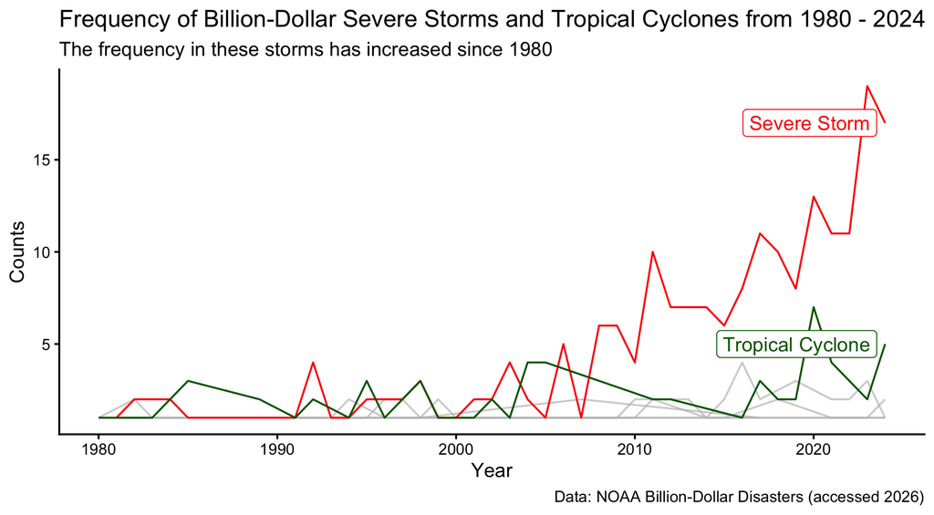

```r
#your code here
df_disasters %>%
  count(year, disaster) %>% #count the number of disasters and include the year
  ggplot(aes(x = year, y = n, group = disaster, color = disaster)) +
  geom_line() + #create line chart by frequency and type of disaster
  scale_x_continuous(breaks = breaks_pretty()) + # make an x-axis with only integers
  gghighlight::gghighlight(disaster %in% c("Severe Storm", "Tropical Cyclone")) + #highlight these natural disasters
  scale_color_manual(values = c("Severe Storm" = "Red", "Tropical Cyclone" = "Dark Green")) + #change gghighlight color
  theme_classic()+ #change theme
  labs( y = "Counts", x = "Year", title = "Frequency of Billion-Dollar Severe Storms and Tropical Cyclones from 1980 - 2024",
       subtitle = "The frequency in these storms has increased since 1980",
       caption = "Data: NOAA Billion-Dollar Disasters (accessed 2026)") #add appropriate title, caption, subtitle, and change axis labels
```

What do you notice about the trends over time in the frequency and/or cost of disasters? Anything unexpected?

**NoteYour Answer**

Type your response here. The frequency in billion-dollar severe storms has increased more than any other natural disaster. I expected all disasters to increase over time given that climate change has increased the intensity of natural disasters. Although this may be true, the data set has only recorded the number of billion-dollar disasters and the nature of a given disaster, for example a drought, might be more difficult to measure in damage costs. Droughts are a disaster that is measured over a longer period of time than compared to a more acute event like a severe storm.

## Q3: Reflection

1. What are your variables of interest and what kinds of data (e.g., numeric, categorical, ordered, etc.) are they?

**NoteYour Answer**

Type your response here. My variables of interest are year, frequency, and disaster. Year and the created frequency (n) variable from the count(disaster) function are both numeric and disaster is categorical.

2. How did you decide which type of graphic form was best suited for answering the question? What alternative graphic forms could you have used instead? Why did you settle on this particular form?

**NoteYour Answer**

Type your response here. A line graph was appropriate because it is easy to see the trend in disasters over time. Highlighting disasters with the most dramatic change in frequency made the graph more readable since the other disasters with less obvious trends faded into the background.Also, highlighting all of the disasters would have made the graph too messy to interpret. Alternative forms that could have worked are histograms or a violin dot plot. I thought a line chart was going to be the simplest graph to read and have a high data to ink ratio compared to the other graphs mentioned.

3. What modifications did you make to this viz to improve readability and accessibility?

**NoteYour Answer**

Type your response here. I changed the theme to classic so the background was white instead of gray. I highlighted certain disasters instead of letting all of the disasters be highlighted to improve the readability of the graph. The colors of the highlighted disasters are distinct to improve accessibility. The Y axis was renamed from “n” to “Counts” to make the labels more obvious and unambiguous to an end-user. I also changed the scale in the x-axis to only include integers.

4. Is there anything you wanted to implement but didn’t know how? If so, describe it.

**NoteYour Answer**

Type your response here. I wanted to facet wrap the graph to make small multiples by decade. I was able to make a new column for the decade label but I was not sure how to make the x-axis specific for the small multiple. When I ran the code each graph had 1980-2024 in the x-axis and made the graphs harder to read.

## Q4: Critique the original graph from NOAA

[figure not shown]

NOAA Billion-Dollar Disaster Events (1980–2024)

This plot appears on NOAA’s official Billion-Dollar Disaster website and summarizes annual disaster frequency and cost.

1. Describe the graphic
- What type(s) of chart(s) are used?
- What variables are encoded? How are they mapped to visual channels (e.g., position, color, size)?
- What is the intended takeaway?

2. Assess strengths
- What aspects of the chart help communicate the intended message clearly?
- Is there anything done particularly well in terms of accessibility, color use, or labeling?

**NoteYour Answer**

Type your response here. This graph is effective in communicating how the trend in the total natural disasters has increased since 1980. I think the purpose of this graph was to observe natural disaster trends from a wider point of view by having data over a long period of time. This can be shown in the overall length of the bar chart as you move through time as well as the upward trend in the line graph. The colors used in the bar chart are ordered in a way where colors that are next to each other are distinct and the x-axis is labelled every other year to improve the readability by making the axis less crowded. The alternating white and grey background makes it easier to guide your eyes to the bar charts than having a solid colored background.

3. Assess limitations
- What elements of the chart are **confusing, cluttered, or potentially misleading**?
- Are any visual encodings hard to interpret?
- Does the chart overcomplicate the message or try to show too much?

4. Recommend improvements
- Suggest **2–3 specific changes** that would improve the effectiveness of the chart.
- Would you consider separating out the lines from the stacked bars? Using interactivity? Changing the layout?

**NoteYour Answer**

Type your response here. 1. Creating two different charts, one for the stacked bars and one for the line chart. 2. Creating a user interactive guide where they can select the time period and/or individual or a select group of disasters. 3. Changing the color of the 95% CI area to a darker gray to improve readability.

## BONUS: Create an alternative data visualization from the dataset

- Use the from Data to Viz tool [here](https://www.data-to-viz.com/) to help determine graph types you can use that are different from what you have implemented above
- Create a new visualization that uses a different type of graph than the one you created in Q2.

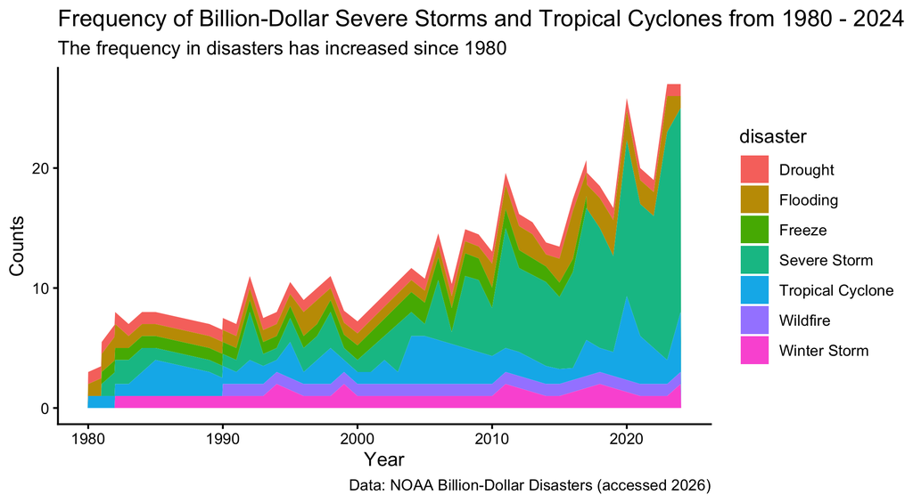

```r
#your code here
df_disasters %>%
  count(year, disaster) %>% #count the number of disasters and include the year
  ggplot(aes(x = year, y = n, group = disaster, fill = disaster))+
  geom_area()+ #create stacked area graph
  theme_classic() +
  labs( y = "Counts", x = "Year", title = "Frequency of Billion-Dollar Severe Storms and Tropical Cyclones from 1980 - 2024",
       subtitle = "The frequency in disasters has increased since 1980",
       caption = "Data: NOAA Billion-Dollar Disasters (accessed 2026)") #add appropriate title, caption, subtitle, and change axis labels
```

**NoteYour Reflection**

Type your reflection here. I thought the linked website was very informative on the most effective visualization for a given dataset. There were some visualizations on the website that I would like to learn how to create in the future (e.g heat map, snakey diagram, spider plot). In my graph above I thought it is effective in displaying the message that the overall number of billion-dollar disasters has greatly increased over time. I understand that the colors together are very bright and can strain your eyes. I tried to desaturate all of the colors but I could not figure out how to do that in an easy way.

## How I used GenAI?

Describe how GenAI is used in producing this homework, include prompt, date, model version, and link to chat history.

**NoteYour Answer**

Type your response here. I used ChatGPT for general questions about ggplot and debugging. This chat includes multiple prompts I used while doing this homework. accessed 5/31/2026 version:GPT-5.5 https://chatgpt.com/share/6a1df56f-c410-83ea-94b6-f25300aea7a4

## Save and Push Your Work

Remember to save your `.qmd` and render the HTML output before committing to GitHub.

```bash
git add 2-hw2.qmd 2-hw2.html
git commit -m "Complete Homework 2"
git push
```